# Lecture 10 — Optical Flow

Lecture 10

Kaveh Fathian

Computer Science Department, Colorado School of Mines

## Learning Objectives

By the end of this lecture, you should be able to:

- Explain optical flow, distinguish sparse and dense estimates, and describe their applications.
- Derive the optical flow constraint from brightness constancy and explain the aperture problem.
- Explain how Lucas–Kanade estimates motion within a window, why corners are suitable for tracking, and how image pyramids help handle larger motion.
- Use OpenCV to track selected points and estimate dense optical flow.

## Fundamental Equations of Computer Vision

[output not shown]

## What Is Optical Flow?

- **Optical flow** describes the **apparent motion of image points between video frames**.
- A point at $(x,y)$ moves to $(x+u,y+v)$, giving a displacement vector $(u,v)$.

[figure not shown]

Note: Image coordinates increase to the right and downward.

- Motion can result from movement of the **object**, the **camera**, or **both**.
- $(u,v)$ describes displacement in image pixels, not directly the object’s 3D motion.

## Sparse and Dense Optical Flow

- **Sparse optical flow:** estimated displacement at *selected image points*, often corners.
- **Dense optical flow:** estimated displacement at *every pixel*.

[figure not shown]

Only a subset of the dense field’s arrows is displayed for readability.

- Sparse estimates are often used for tracking selected features.
- Dense estimates describe motion across the image, including regions with different motions.

## Visualizing Optical Flow

Optical flow is often displayed using **arrows** or **colors**.

[figure not shown]

- **Arrows:** direction indicates where a point moves; length represents displacement magnitude.
- **Colors:** encode a dense field. E.g., hue represents direction; stronger color away from white represents larger displacement.

## Optical Flow Applications

### Optical Computer Mouse

[figure not shown]

jason@heqingele.com; pexels

### Pedestrian Detection & Motion Estimation

[video not shown]

[figure not shown]

[Watch on YouTube](https://www.youtube.com/watch?v=e_TeY6QRp4c)

### Visual Odometry & SLAM

[figure not shown]

Rainer Hessmer

## Optical Flow Applications

### Super Resolution

[figure not shown]

Liu & Sun, CVPR 2011; TPAMI 2014

### Super Slow Motion

[video not shown]

[figure not shown]

Jiang et al., CVPR 2018  
[Watch on YouTube](https://www.youtube.com/watch?v=MjViy6kyiqs)

### Image Unblur

[figure not shown]

Google Pixel 6: Face Unblur

## Can We Use Feature Matching?

Can we estimate optical flow by detecting SIFT features and matching them between frames?

- Yes—matched features provide **sparse displacement estimates**.
- But an object may have no distinctive appearance separating it from its background.

Can you locate the hidden object? Click the texture or advance once.

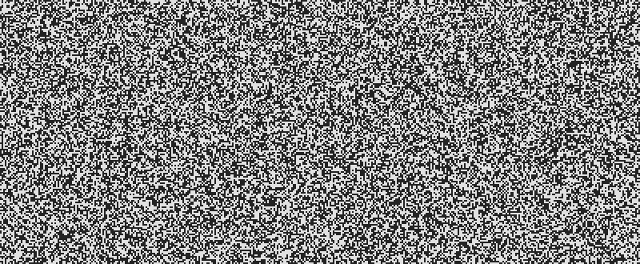

[interactive chart not shown]

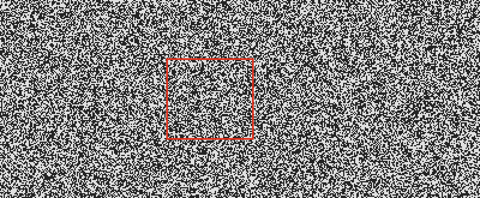

Sometimes motion reveals structure that is difficult to see in a single frame.

Moving region outlined in red for print.

Can we **estimate motion directly from changes in image intensity**, without detecting and matching keypoints?

## Brightness Constancy

What stays the same as a point moves between frames?

- **Brightness constancy:** a scene point keeps its intensity as it moves:
  $$I(x,y,t) = I(x+u,\ y+v,\ t+1)$$

[figure not shown]

- The marked point has the same intensity in both frames; only its position changes.
- Brightness constancy holds when lighting is constant, the surface looks the same from slightly different viewpoints, and the frames are close in time.

## Optical Flow Equation

Rearrange brightness constancy and apply a first-order Taylor expansion:

$$\begin{aligned}
0 &= I(x+u,y+v,t+1) - I(x,y,t)\\[2pt]
&\approx I(x,y,t) + I_x u + I_y v + I_t - I(x,y,t)\\[2pt]
&= I_x u + I_y v + I_t\\[2pt]
&= \nabla I \cdot [u,\ v]^T + I_t
\end{aligned}$$

- $I_x, I_y$: spatial image gradients.
- $I_t \approx I(x,y,t+1) - I(x,y,t)$: change of intensity at a fixed pixel.

**Optical Flow Equation**

$$I_x u + I_y v + I_t = 0$$

**When is this approximation bad?** When $u$ or $v$ is large compared with how smoothly the image varies.

## Why Do Spatial Gradients Reveal Motion?

What do static image gradients have to do with motion?

- Consider a 1D intensity profile that shifts right by $u$ pixels. Brightness constancy simplifies to $I_x u + I_t = 0$.

[figure not shown]

- On a slope, shifting the profile changes the intensity at a fixed pixel by about $-I_x u$, so $u \approx -I_t/I_x$.
- In a flat region, the intensity barely changes: the motion is nearly invisible.

## Brightness Constancy Example

[figure not shown]

Pixel values: black = 0, white = 1. Derivatives use forward differences.

$$I_x = 1,\qquad I_y = 0,\qquad I_t = 1$$

$$I_x u + I_y v + I_t = 0$$
$$\Rightarrow\; 1\,u + 0\,v + 1 = 0$$

- What’s $u$?
  - $u = -I_t/I_x = -1$: the edge moved one pixel left.
- What’s $v$?
  - Any value satisfies the equation. Vertical motion of a vertical edge leaves no trace.

## The Aperture Problem

If Lucas–Kanade window sees only a straight edge, many different motions look the same:

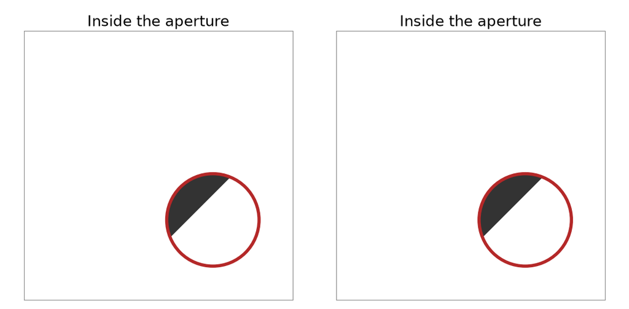

- Inside the aperture, only motion perpendicular to the edge is observable.

## One Equation, Two Unknowns

Given $I_x, I_y, I_t$, can we uniquely recover $(u,v)$ from the optical flow equation $I_x u + I_y v + I_t = 0$?

- **No**: one equation per pixel, two unknowns.
- If $(u,v)$ satisfies $\nabla I\cdot(u,v) + I_t = 0$, so does $(u+u',\ v+v')$ for any $(u',v')$ with $\nabla I\cdot(u',v') = 0$.
- Only the flow component along the gradient can be recovered:
  $$u_n = -\frac{I_t}{\lVert\nabla I\rVert}$$
- The component parallel to the edge is lost.

[figure not shown]

## Lucas–Kanade: More Equations from a Window

- Each pixel gives 1 equation and 2 unknowns. How do we get more equations?
- Assume **spatial coherence**: pixels in a small window move together and share the same $(u,v)$.
- A $5\times5$ window gives 25 equations:

$$\underbrace{\begin{bmatrix}
I_x(p_1) & I_y(p_1)\\
\vdots & \vdots\\
I_x(p_{25}) & I_y(p_{25})
\end{bmatrix}}_{A\ (25\times2)}
\underbrace{\begin{bmatrix} u\\ v \end{bmatrix}}_{\mathbf d\ (2\times1)}
=
\underbrace{-\begin{bmatrix}
I_t(p_1)\\
\vdots\\
I_t(p_{25})
\end{bmatrix}}_{\mathbf b\ (25\times1)}$$

B. Lucas and T. Kanade, “An iterative image registration technique with an application to stereo vision,” IJCAI, 1981.

[figure not shown]

Frame 2 is a synthetic shift of image by $(u,v)=(0.6,-0.4)$ px.

## Solving for $(u,v)$

Least squares:

$$A^TA\,\mathbf d = A^T\mathbf b
\quad\Rightarrow\quad
\mathbf d = (A^TA)^{-1}A^T\mathbf b$$

Summing over the pixels in the window:

$$\underbrace{\begin{bmatrix}
\sum I_xI_x & \sum I_xI_y\\
\sum I_xI_y & \sum I_yI_y
\end{bmatrix}}_{A^TA}
\begin{bmatrix} u\\ v \end{bmatrix}
=
\underbrace{-\begin{bmatrix}
\sum I_xI_t\\
\sum I_yI_t
\end{bmatrix}}_{A^T\mathbf b}$$

- Similar to the Hough transform, each pixel contributes a line in parameter space.
- Least squares finds the $(u,v)$ that best satisfies all lines.

[figure not shown]

The $v$ axis points down, as in image coordinates.

## When Can We Solve for $(u,v)$?

- $A^TA$ must be **invertible**: in a uniform region it is singular.
- $A^TA$ must **not be too small**: otherwise noise dominates.
- $A^TA$ must be **well-conditioned**: a large $\lambda_1/\lambda_2$ indicates an edge.
- $A^TA$ is the second moment matrix $M$ from Harris corners: **good corners** give reliable flow.

[figure not shown]

Orange dots: estimates from 40 frame pairs with independent noise. Green star: known shift. At the edge, $u$ is accurate but $v$ is not.

## Lucas–Kanade Implementation

**Lucas–Kanade (one window)**

1. Compute $I_x, I_y$ from a smoothed frame and $I_t$ from the frame difference.
2. Sum products over the window to form $A^TA$ and $A^T\mathbf b$.
3. Skip the window if the smaller eigenvalue of $A^TA$ is too small.
4. Solve the $2\times2$ system for $(u,v)$.

Simplified implementation:

```python
def lucas_kanade_window(frame1, frame2, x, y, half_size=2, min_eigenvalue=100):
    gradient_x, gradient_y = image_gradients(frame1)
    temporal_change = frame2 - frame1
    window = np.s_[y-half_size:y+half_size+1, x-half_size:x+half_size+1]
    Ix, Iy, It = gradient_x[window], gradient_y[window], temporal_change[window]

    ATA = np.array([[np.sum(Ix*Ix), np.sum(Ix*Iy)],
                    [np.sum(Ix*Iy), np.sum(Iy*Iy)]])
    ATb = -np.array([np.sum(Ix*It), np.sum(Iy*It)])

    if np.linalg.eigvalsh(ATA)[0] < min_eigenvalue:
        return None
    return np.linalg.solve(ATA, ATb)
```

## When Does Lucas–Kanade Fail?

- **Large motion:** the Taylor approximation breaks down.
- **Occlusions:** points appear or disappear.
- **Lighting changes, noise:** brightness constancy is violated.
- **Textureless regions:** $A^TA$ is nearly singular.
- **Edges (aperture problem):** $A^TA$ is ill-conditioned.

[figure not shown]

Synthetic horizontal shifts of the street image; median estimate over the most textured $5\times5$ windows.

## Coarse-to-Fine Estimation

- Each Gaussian pyramid level **halves the image size**, so it also **halves the displacement**.
- At a coarse enough level, the motion is small enough for the linearization to hold.

[figure not shown]

## Coarse-to-Fine Algorithm

**Coarse-to-Fine Lucas–Kanade**

1. Build Gaussian pyramids of both frames.
2. Estimate flow at the coarsest level.
3. Upsample the flow to the next level and double its values.
4. Warp frame 2 toward frame 1 using the current flow.
5. Estimate the remaining flow with Lucas–Kanade and add it.
6. Repeat until the finest level.

Warping uses the current flow estimate $(u_0,v_0)$ to resample frame 2, pulling each pixel back by the motion already found:
$$I_2^{\text{warped}}(x,y) = I_2(x+u_0,\ y+v_0)$$

[figure not shown]

Same synthetic shifts as before. At the coarsest of 3 levels, an 8 px shift becomes 2 px.

## Lucas–Kanade in OpenCV: Selecting Points

```python
corners = cv2.goodFeaturesToTrack(
    gray1, maxCorners=300, qualityLevel=0.01,
    minDistance=10, blockSize=7)
```

- Keeps points where the **smaller eigenvalue** of $A^TA$ is large: the windows where Lucas–Kanade is solvable.
- `qualityLevel`: keep points whose smaller eigenvalue is at least 1% of the strongest one.
- `minDistance`: minimum spacing between points (pixels).
- `blockSize`: window size used to form $A^TA$.

J. Shi and C. Tomasi, [“Good Features to Track,”](https://publications.ri.cmu.edu/good-features-to-track) CVPR, 1994.  
[OpenCV: Shi–Tomasi Corner Detector](https://docs.opencv.org/4.x/d4/d8c/tutorial_py_shi_tomasi.html).

[figure not shown]

## Lucas–Kanade in OpenCV: Tracking

```python
next_points, status, _ = cv2.calcOpticalFlowPyrLK(
    gray1, gray2, corners, None, winSize=(15, 15), maxLevel=3)

tracked = status.ravel() == 1
displacement = (next_points - corners)[tracked, 0]
```

- `winSize`: the Lucas–Kanade window at each pyramid level.
- `maxLevel`: number of pyramid levels above the original (0 = no pyramid).
- `status`: 1 if the point was tracked; keep only those.
- `displacement`: $(u,v)$ for each retained point.
- OpenCV point arrays have shape $(N,1,2)$; `[:, 0]` gives an $(N,2)$ array of coordinates.

[figure not shown]

Frames 100 → 101, zoomed to the walkers. Arrows are drawn 5× longer than the displacement; yellow points moved ≤ 1 px.

## Lucas–Kanade: Complete Video Example

```python
import cv2
import numpy as np

GREEN, RED = (0, 255, 0), (0, 0, 255)  # OpenCV colors are BGR

def track_points(gray1, gray2, points):
    # Lucas-Kanade from gray1 to gray2, then back to gray1.
    next_points, status, error = cv2.calcOpticalFlowPyrLK(
        gray1, gray2, points, None, winSize=(15, 15), maxLevel=3)
    back_points, back_status, _ = cv2.calcOpticalFlowPyrLK(
        gray2, gray1, next_points, None, winSize=(15, 15), maxLevel=3)
    # Keep points found in both directions that came back within 1 px.
    returned = np.linalg.norm(points - back_points, axis=1) < 1
    tracked = (status.ravel() == 1) & (back_status.ravel() == 1) & returned
    return next_points, tracked

video = cv2.VideoCapture("vtest.avi")
tracks = []  # one track per point: its list of (x, y) positions
gray1 = None
frame_count = 0

while True:
    ok, frame = video.read()
    if not ok:  # end of the video
        break
    gray2 = cv2.cvtColor(frame, cv2.COLOR_BGR2GRAY)

    # Move each track's latest point to gray2; keep its last 10 positions.
    if gray1 is not None and tracks:
        points = np.float32([track[-1] for track in tracks])
        next_points, tracked = track_points(gray1, gray2, points)
        tracks = [(track + [point])[-10:] for track, point, keep
                  in zip(tracks, next_points, tracked) if keep]

    # Every 10 frames, add new points at least 10 px from those already tracked.
    if frame_count % 10 == 0:
        mask = np.full(gray2.shape, 255, np.uint8)
        for track in tracks:
            cv2.circle(mask, np.int32(track[-1]), 10, 0, -1)
        corners = cv2.goodFeaturesToTrack(gray2, maxCorners=300, qualityLevel=0.01,
                                          minDistance=10, blockSize=7, mask=mask)
        tracks += [[point] for point in corners[:, 0]]

    # Draw tails (green) and current positions (red).
    for track in tracks:
        cv2.polylines(frame, [np.int32(track)], False, GREEN, 2, cv2.LINE_AA)
        cv2.circle(frame, np.int32(track[-1]), 2, RED, -1, cv2.LINE_AA)
    cv2.imshow("Lucas-Kanade tracking", frame)
    if cv2.waitKey(100) == 27:  # 100 ms per frame (10 fps); Esc quits
        break

    gray1 = gray2
    frame_count += 1

video.release()
cv2.destroyAllWindows()
```

## Tracking Points Through the Video

- Track forward and backward; retain points that return within 1 px of their starting positions.
- Green tails show each point’s last 10 positions; red dots show current positions.
- Every 10 frames, detect new points away from those already tracked.

[video not shown]

[figure not shown]

## Dense Optical Flow: Farnebäck

```python
flow = cv2.calcOpticalFlowFarneback(
    gray1, gray2, None, pyr_scale=0.5, levels=3, winsize=15,
    iterations=3, poly_n=5, poly_sigma=1.2, flags=0)
```

- `flow` has shape (height, width, 2): `flow[y, x]` $=(u,v)$ at every pixel.
- Fits a quadratic polynomial to each neighborhood and estimates how it shifts between frames.
- `pyr_scale`: scale factor between pyramid levels.
- `levels`: total number of levels, including the original image.
- `winsize`: averaging window; larger is smoother and more robust to noise, but blurs motion boundaries.
- `iterations`: refinements per pyramid level.
- `poly_n`, `poly_sigma`: neighborhood size and smoothing for the polynomial fit.

[figure not shown]

Hue: direction; saturation: magnitude, saturating at 5 px. White means no motion.

## Dense Optical Flow: DIS

```python
dis = cv2.DISOpticalFlow_create(cv2.DISOPTICAL_FLOW_PRESET_MEDIUM)
flow = dis.calc(gray1, gray2, None)
```

- **DIS**: Dense Inverse Search.
- Runs a fast Lucas–Kanade-style search on a grid of patches, then combines and refines their motion estimates into a dense field.
- Presets (`ULTRAFAST`, `FAST`, `MEDIUM`) trade accuracy for speed.
- Returns the same (height, width, 2) flow array format as Farnebäck.
- Use the same color scale to compare the two methods.

[figure not shown]

Hue: direction; saturation: magnitude, saturating at 5 px. White means no motion.

## Dense Optical Flow: Complete Video Example

```python
import cv2
import numpy as np

def flow_to_bgr(flow, max_flow=5):
    # Hue: direction. Saturation: magnitude. White: no motion.
    magnitude, angle = cv2.cartToPolar(
        flow[..., 0], flow[..., 1], angleInDegrees=True)
    hsv = np.zeros(flow.shape[:2] + (3,), np.uint8)
    hsv[..., 0] = angle / 2
    hsv[..., 1] = np.clip(255 * magnitude / max_flow, 0, 255)
    hsv[..., 2] = 255
    return cv2.cvtColor(hsv, cv2.COLOR_HSV2BGR)

video = cv2.VideoCapture("vtest.avi")
dis = cv2.DISOpticalFlow_create(cv2.DISOPTICAL_FLOW_PRESET_MEDIUM)

_, previous = video.read()
gray1 = cv2.cvtColor(previous, cv2.COLOR_BGR2GRAY)

while True:
    ok, current = video.read()
    if not ok:
        break
    gray2 = cv2.cvtColor(current, cv2.COLOR_BGR2GRAY)

    farneback = cv2.calcOpticalFlowFarneback(
        gray1, gray2, None, pyr_scale=0.5, levels=3, winsize=15,
        iterations=3, poly_n=5, poly_sigma=1.2, flags=0)
    dis_flow = dis.calc(gray1, gray2, None)

    # Forward flow is defined at pixels in the previous frame.
    cv2.imshow("Video", previous)
    cv2.imshow("Farneback", flow_to_bgr(farneback))
    cv2.imshow("DIS", flow_to_bgr(dis_flow))

    previous, gray1 = current, gray2
    if cv2.waitKey(100) == 27:  # Esc quits.
        break

video.release()
cv2.destroyAllWindows()
```

## Comparing Dense Optical Flow

- Both methods estimate motion at every pixel between consecutive frames.
- Compare the walkers, motion boundaries, and nearly stationary background.
- Both displays use the same color scale: white means no motion; saturation reaches its maximum at 5 px.

[video not shown]

[figure not shown]

## Optical Flow in OpenCV

| Method | Function | Output | Module |
| --- | --- | --- | --- |
| Pyramidal Lucas–Kanade | `cv2.calcOpticalFlowPyrLK` | Sparse | main |
| Farnebäck | `cv2.calcOpticalFlowFarneback` | Dense | main |
| DIS | `cv2.DISOpticalFlow_create` | Dense | main |
| Dual TV-L1 | `cv2.optflow.DualTVL1OpticalFlow_create` | Dense | contrib |
| DeepFlow | `cv2.optflow.createOptFlow_DeepFlow` | Dense | contrib |
| Sparse-to-dense | `cv2.optflow.calcOpticalFlowSparseToDense` | Dense | contrib |
| Robust local flow (RLOF) | `cv2.optflow.calcOpticalFlowSparseRLOF`, `cv2.optflow.calcOpticalFlowDenseRLOF` | Both | contrib |

- **Sparse:** track selected points (e.g., for visual odometry).
- **Dense:** a vector at every pixel (e.g., motion segmentation).
- `contrib` methods require OpenCV built with the contrib modules.

## Key Takeaways

- Optical flow describes apparent motion between images. Sparse methods estimate motion at selected points; dense methods estimate a vector at every pixel.
- Brightness constancy and a small-motion approximation give $I_xu + I_yv + I_t = 0$: one equation for two unknowns.
- Lucas–Kanade assumes shared motion within a small window and combines its pixel equations using least squares. Reliable estimates require intensity variation in two directions—the same condition used to identify corners.
- Coarse-to-fine estimation reduces apparent displacement, then refines the estimate through warping and residual motion updates.

**When Is Motion Reliable?**

Flat regions provide little motion information; a straight edge reveals only motion normal to the edge. Corners and texture help resolve both components, but lighting changes, occlusion, and large motion can still cause errors.